# Reproducible Research: Peer Assessment 1

Mario Maffioli

Thursday, March 05, 2015

## load required libraries

```r
library(dplyr, warn.conflicts = FALSE )
library(xtable)
library(chron)
library(lattice)
```

## Loading and preprocessing the data

Unzip the activity file and load it into memory

```r
rm(list=ls())
unzip("Activity.zip")
activity_raw <- read.csv("activity.csv")
```

Preprocess data sets required for analysis

```r
# Summarize raw data to determine steps per date
activity_raw_bydate <-
    activity_raw %>% group_by(date)%>%
    summarise(steps = sum(steps, na.rm=T))

# Summarize raw data to get the mean of steps per interval
activity_raw_byinterval <-
    activity_raw %>% group_by(interval)%>%
    summarise(steps_mean = mean(steps, na.rm=T))


# replace NA step values with corresponding interval mean

activity_no_na <- activity_raw

# convert interval ids to factors
activity_no_na$interval  <- as.factor(activity_no_na$interval)

# create named vector to use as look-up table
named_means_vector <-
    activity_raw_byinterval$steps_mean
names(named_means_vector) <-
    activity_raw_byinterval$interval

# Extract indices of rows with NA values in steps
indx <- which(is.na(activity_raw$steps))

# Replace NA values with corresponding interval means
activity_no_na[indx,]$steps <-
        named_means_vector[activity_no_na[indx,]$interval ]

# summarize imputed NA file to get steps per day
activity_noNA_bydate <-
    activity_no_na %>% group_by(date)%>%
    summarise(steps = sum(steps, na.rm=T))

# create augmented data frame with wend column
activity_no_na_day <-
    activity_no_na %>%
        mutate(day=is.weekend(as.Date(date)))

# convert Wend  to factor
activity_no_na_day$day  <- as.factor(activity_no_na_day$day)

# label factor levels
levels(activity_no_na_day$day) <-
    c("weekday", "weekend")

# summarize imputed NA file by interval and week day
activity_no_na_day_byinterval <-
    activity_no_na_day %>% group_by(interval, day)%>%
    summarise(steps_mean = mean(steps))

# Compute means by date for both raw and imputed NA data sets
means <- c(mean(activity_raw_bydate$steps, na.rm=T), mean(activity_noNA_bydate$steps))

# Compute medians for raw and imputed NA data sets
medians <- c(median(activity_raw_bydate$steps, na.rm=T), median(activity_noNA_bydate$steps))

# build data frame for mean and median comparison
compare_mean_median <- data_frame(mean=means, median=medians)
rownames(compare_mean_median) <- c("with NAs","imputed NAs")
```

## What is mean total number of steps taken per day?

1. Total number of steps taken per day

Table with total number of steps taken per day

```r
tbl <- xtable(activity_raw_bydate,
           caption="Fig. 1.0\n Steps by date")
align(tbl) <- "|r|r|r|"
print (tbl,
      NA.string="NA",
      type = "html"
      )
```

Fig. 1.0 Steps by date

|  | date | steps |
| --- | --- | --- |
| 1 | 2012-10-01 | 0 |
| 2 | 2012-10-02 | 126 |
| 3 | 2012-10-03 | 11352 |
| 4 | 2012-10-04 | 12116 |
| 5 | 2012-10-05 | 13294 |
| 6 | 2012-10-06 | 15420 |
| 7 | 2012-10-07 | 11015 |
| 8 | 2012-10-08 | 0 |
| 9 | 2012-10-09 | 12811 |
| 10 | 2012-10-10 | 9900 |
| 11 | 2012-10-11 | 10304 |
| 12 | 2012-10-12 | 17382 |
| 13 | 2012-10-13 | 12426 |
| 14 | 2012-10-14 | 15098 |
| 15 | 2012-10-15 | 10139 |
| 16 | 2012-10-16 | 15084 |
| 17 | 2012-10-17 | 13452 |
| 18 | 2012-10-18 | 10056 |
| 19 | 2012-10-19 | 11829 |
| 20 | 2012-10-20 | 10395 |
| 21 | 2012-10-21 | 8821 |
| 22 | 2012-10-22 | 13460 |
| 23 | 2012-10-23 | 8918 |
| 24 | 2012-10-24 | 8355 |
| 25 | 2012-10-25 | 2492 |
| 26 | 2012-10-26 | 6778 |
| 27 | 2012-10-27 | 10119 |
| 28 | 2012-10-28 | 11458 |
| 29 | 2012-10-29 | 5018 |
| 30 | 2012-10-30 | 9819 |
| 31 | 2012-10-31 | 15414 |
| 32 | 2012-11-01 | 0 |
| 33 | 2012-11-02 | 10600 |
| 34 | 2012-11-03 | 10571 |
| 35 | 2012-11-04 | 0 |
| 36 | 2012-11-05 | 10439 |
| 37 | 2012-11-06 | 8334 |
| 38 | 2012-11-07 | 12883 |
| 39 | 2012-11-08 | 3219 |
| 40 | 2012-11-09 | 0 |
| 41 | 2012-11-10 | 0 |
| 42 | 2012-11-11 | 12608 |
| 43 | 2012-11-12 | 10765 |
| 44 | 2012-11-13 | 7336 |
| 45 | 2012-11-14 | 0 |
| 46 | 2012-11-15 | 41 |
| 47 | 2012-11-16 | 5441 |
| 48 | 2012-11-17 | 14339 |
| 49 | 2012-11-18 | 15110 |
| 50 | 2012-11-19 | 8841 |
| 51 | 2012-11-20 | 4472 |
| 52 | 2012-11-21 | 12787 |
| 53 | 2012-11-22 | 20427 |
| 54 | 2012-11-23 | 21194 |
| 55 | 2012-11-24 | 14478 |
| 56 | 2012-11-25 | 11834 |
| 57 | 2012-11-26 | 11162 |
| 58 | 2012-11-27 | 13646 |
| 59 | 2012-11-28 | 10183 |
| 60 | 2012-11-29 | 7047 |
| 61 | 2012-11-30 | 0 |

Create and display histogram

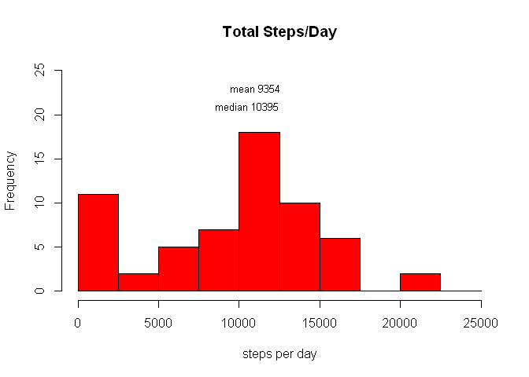

```r
par(mfrow = c(1,1))
hist1 <- hist(activity_raw_bydate$steps, breaks=seq(0,25000,2500),xlab = "steps per day", main="Total Steps/Day", col="red", ylim=c(0,25))
text(11000, 23, "mean 9354",cex = .8)
text(10500, 21, "median 10395",cex = .8)
```

Report mean and median steps taken per day

```r
mean(activity_raw_bydate$steps, na.rm=T)
```

```
## [1] 9354.23
```

```r
median(activity_raw_bydate$steps, na.rm=T)
```

```
## [1] 10395
```

## What is the average daily activity pattern?

Table showing first 20 rows of average number of steps taken per interval

```r
tbl2 <- xtable(head(activity_raw_byinterval,20),
           caption="Fig. 2.0\n Steps by interval")
align(tbl2) <- "|r|c|r|"
print (tbl2,
      NA.string="NA",
      type = "html"
      )
```

Fig. 2.0 Steps by interval

|  | interval | steps_mean |
| --- | --- | --- |
| 1 | 0 | 1.72 |
| 2 | 5 | 0.34 |
| 3 | 10 | 0.13 |
| 4 | 15 | 0.15 |
| 5 | 20 | 0.08 |
| 6 | 25 | 2.09 |
| 7 | 30 | 0.53 |
| 8 | 35 | 0.87 |
| 9 | 40 | 0.00 |
| 10 | 45 | 1.47 |
| 11 | 50 | 0.30 |
| 12 | 55 | 0.13 |
| 13 | 100 | 0.32 |
| 14 | 105 | 0.68 |
| 15 | 110 | 0.15 |
| 16 | 115 | 0.34 |
| 17 | 120 | 0.00 |
| 18 | 125 | 1.11 |
| 19 | 130 | 1.83 |
| 20 | 135 | 0.17 |

Select interval with highest average number of steps

```r
max_step_mean <- filter(activity_raw_byinterval,
       steps_mean == max(steps_mean))
max_step_mean
```

```
## Source: local data frame [1 x 2]
##
##   interval steps_mean
## 1      835   206.1698
```

Plot time series of average steps per interval across all days

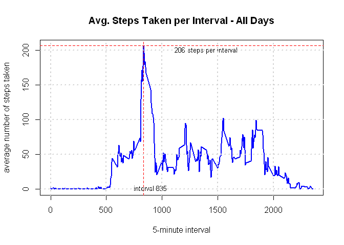

```r
x <- activity_raw_byinterval$interval
y <- activity_raw_byinterval$steps_mean
plot(x,y, type="l", xlab=" 5-minute interval ",
     ylab="average number of steps taken",
     main="Avg. Steps Taken per Interval - All Days", col= "blue", lwd=2)
abline(v = 835, h= 206.1698, lty=2, col="red")
text(900, 2, "interval 835",cex = .8)
text(1400, 200, "206 steps per interval",cex = .8)
grid(lwd = 2)
```

## Imputing missing values

Find total number of NA’s in steps column of raw activity file

```r
sum(is.na(activity_raw$steps))
```

```
## [1] 2304
```

Devise a strategy for filling in all of the missing values in the dataset. The strategy does not need to be sophisticated. For example, you could use the mean/median for that day, or the mean for that 5-minute interval, etc.

*Strategy*

1. Make a copy of the raw activity data frame.
2. Extract from this copy the indices of the rows with NA values in the ‘steps’ column.
3. Using the ‘activity_raw_byinterval’ data frame, create a named vector with the interval means as values and the interval-id as the names. This vector will the used as a look-up table in the next step.
4. Assign the corresponding interval mean to the ‘steps’ NA value, thus imputing the interval mean as a replacement for the NA value.

Create a new dataset that is equal to the original dataset but with the missing data filled in. THe table below shows the first 20 rows of data with imputed NAs.

```r
tbl3 <- xtable(head(activity_no_na,20),
           caption="Fig. 3.0\n Activity without NAs")
align(tbl3) <- "|r|r|c|r|"
print (tbl3,
      type = "html"
      )
```

Fig. 3.0 Activity without NAs

|  | steps | date | interval |
| --- | --- | --- | --- |
| 1 | 1.72 | 2012-10-01 | 0 |
| 2 | 0.34 | 2012-10-01 | 5 |
| 3 | 0.13 | 2012-10-01 | 10 |
| 4 | 0.15 | 2012-10-01 | 15 |
| 5 | 0.08 | 2012-10-01 | 20 |
| 6 | 2.09 | 2012-10-01 | 25 |
| 7 | 0.53 | 2012-10-01 | 30 |
| 8 | 0.87 | 2012-10-01 | 35 |
| 9 | 0.00 | 2012-10-01 | 40 |
| 10 | 1.47 | 2012-10-01 | 45 |
| 11 | 0.30 | 2012-10-01 | 50 |
| 12 | 0.13 | 2012-10-01 | 55 |
| 13 | 0.32 | 2012-10-01 | 100 |
| 14 | 0.68 | 2012-10-01 | 105 |
| 15 | 0.15 | 2012-10-01 | 110 |
| 16 | 0.34 | 2012-10-01 | 115 |
| 17 | 0.00 | 2012-10-01 | 120 |
| 18 | 1.11 | 2012-10-01 | 125 |
| 19 | 1.83 | 2012-10-01 | 130 |
| 20 | 0.17 | 2012-10-01 | 135 |

Make a histogram of the total number of steps taken each day (with the imputed NA values)

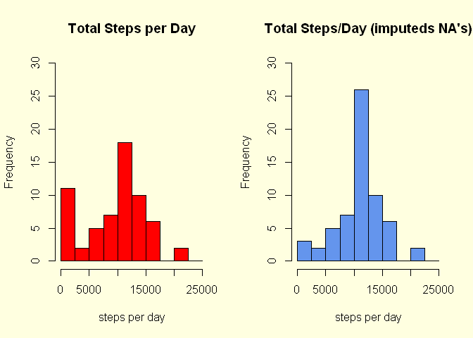

```r
op <- par(mfrow = c(1, 2), bg = "lightyellow")

plot(hist1,xlab = "steps per day", main="Total Steps per Day", col="red", ylim=c(0,30))

hist2 <- hist(activity_noNA_bydate$steps, breaks=seq(0,25000,2500),xlab = "steps per day", main="Total Steps/Day (imputeds NA's)", col="cornflowerblue", ylim=c(0,30))
```

```r
par(op)
```

Compare means and medians with/without NAs

```r
tbl4 <- xtable(compare_mean_median,
           caption="Fig. 4.0\n Mean and medians with/without NAs")
align(tbl4) <- "|l|c|c|"
print (tbl4,
      type = "html"
      )
```

Fig. 4.0 Mean and medians with/without NAs

|  | mean | median |
| --- | --- | --- |
| with NAs | 9354.23 | 10395.00 |
| imputed NAs | 10766.19 | 10766.19 |

## Are there differences in activity patterns between weekdays and weekends?

Panel plot of mean steps per interval for both weekends and weekdays

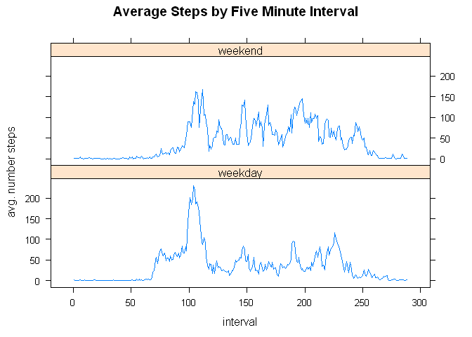

```r
activity_no_na_day_byinterval$interval <- as.integer(activity_no_na_day_byinterval$interval)

# With Latice
xyplot(steps_mean ~ interval | day, data=activity_no_na_day_byinterval, type = "l", layout = c(1, 2),ylab="avg. number steps", main="Average Steps by Five Minute Interval")
```